# Simple Regression

Group 1

2024-04-28

**1.When should we use regression instead of ANOVA?**

We should use regression when we want to estimate the relationship between the continuous outcome variable based on one or more independent variables. Anova is used when we want to compare means across two groups with categorical independent variables. For example, when we want to estimate weight based on age, height, hours of exercise, we should use regression instead of Anova.

**2.Please explain the relationship between SStotal, SSregression, and SSerror.**

In regression analysis, sum of squares total (SStotal) represents the total variability in the dependent variable. SStotal is total of sum of squares regression (SSregression) and sum of squares error (SSerror). SStotal= SSregression + SSerror

SSregression captures the variability in the dependent variable that is explained by the regression model. SSerror accounts for the unexplained variability or residual variance.

For example, in a study looking at relationship between GRE scores and study hours, SStotal represents the total variability in GRE scores, SSregression presents the amount of variability explained by the regression model using study hours, and SSerror shows the unexplained variance in GRE scores.

**3.Please use the following data to build a regression model and write a summary. IV is sugar and DV is calories.**

Sugar: 5, 8, 9, 10, 15, 18, 14, 17, 20, 22, 24, 26, 30 ,30, 32

Calories: 20, 30, 60, 70, 100, 95, 70, 83, 103, 112, 130, 80, 95, 130, 112

Research Question: Is there any relationship between the amount of sugar consumed (IV) and the number of calories consumed (DV)?

Hypothesis Testing: Null Hypothesis (H0) - There is no relationship between sugar consumption and calorie intake.

Alternative Hypothesis (HA) - There is a linear relationship between sugar consumption and calorie intake.

```r
# Data
sugar <- c(5, 8, 9, 10, 15, 18, 14, 17, 20, 22, 24, 26, 30, 30, 32)
calories <- c(20, 30, 60, 70, 100, 95, 70, 83, 103, 112, 130, 80, 95, 130, 112)

# Create a data frame
sug_cal <- data.frame(sugar, calories)
```

```r
# Fit linear regression model
model_sugcal <- lm(calories ~ sugar, data=sug_cal)

summary(model_sugcal)
```

```
##
## Call:
## lm(formula = calories ~ sugar, data = sug_cal)
##
## Residuals:
##     Min      1Q  Median      3Q     Max
## -28.332 -19.060   3.438  11.985  27.758
##
## Coefficients:
##             Estimate Std. Error t value Pr(>|t|)
## (Intercept)  29.1542    12.4132   2.349 0.035315 *
## sugar         3.0453     0.6074   5.013 0.000237 ***
## ---
## Signif. codes:  0 '***' 0.001 '**' 0.01 '*' 0.05 '.' 0.1 ' ' 1
##
## Residual standard error: 19.56 on 13 degrees of freedom
## Multiple R-squared:  0.6591, Adjusted R-squared:  0.6329
## F-statistic: 25.13 on 1 and 13 DF,  p-value: 0.0002373
```

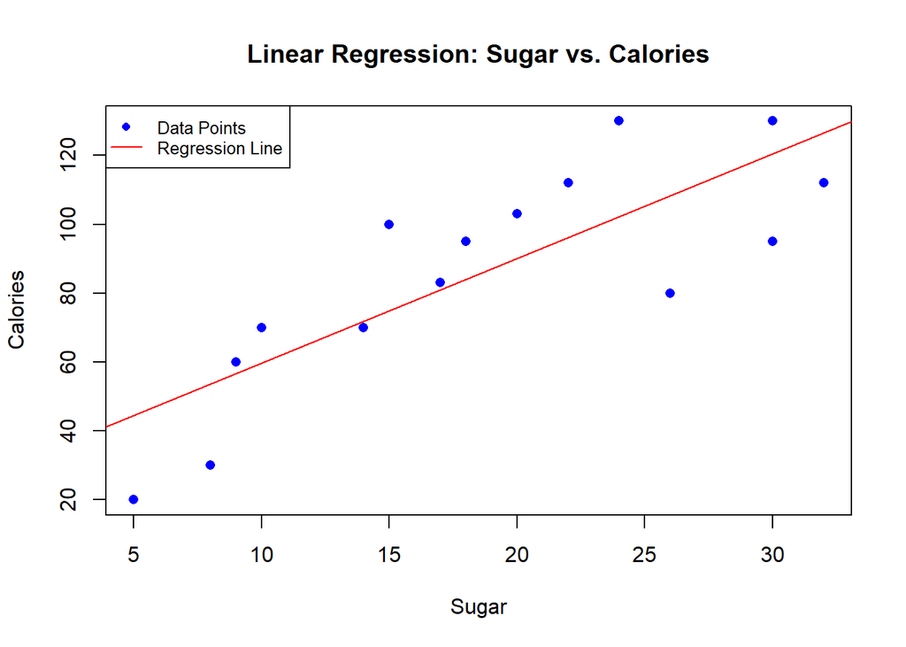

```r
# Plot the regression
plot(sugar, calories, main="Linear Regression: Sugar vs. Calories",
     xlab="Sugar", ylab="Calories", pch=16, col="blue")
 abline(model_sugcal, col="red")
legend("topleft", legend=c("Data Points", "Regression Line"),
       col=c("blue", "red"), pch=c(16, NA), lty=c(NA, 1), cex=0.8)
```

The results indicated a significant positive relationship between sugar consumption and calorie intake with coefficient estimate 3.0453 and p-value less than 0.05 (0.000237). Therefore, we reject the null hypothesis and agree that there is a relationship between sugar consumption and calories intake. These results showed that for every unit increase in sugar consumption, there is an average increase of about 3 calories consumption. The R square value of 0.6591 shows that 65.91% of the variability in calorie intake is explained by the linear relationship with sugar consumption.